#### STAT 755 Lab Report 1

#### Dataset

For this excerise we use the *Longley’s Economic Regression Data Set*. It is available by default as a part of R installation. It is a time-series data consisting of 7 variables and 16 observations. The dataset consists of the following variables.

```r
  data(longley)
  names(longley)
```

```
## [1] "GNP.deflator" "GNP"          "Unemployed"   "Armed.Forces"
## [5] "Population"   "Year"         "Employed"
```

#### Variance-Covariance Matrix

The variance-covarince matrix of the dataset is given below.

```r
  cov_mat = cov(longley)
  rownames(cov_mat)<-names(longley)
  names(cov_mat)<-names(longley)
  knitr::kable(cov_mat, digits = 2)
```

|  | GNP.deflator | GNP | Unemployed | Armed.Forces | Population | Year | Employed |
| --- | --- | --- | --- | --- | --- | --- | --- |
| GNP.deflator | 116.46 | 1063.60 | 625.87 | 349.03 | 73.50 | 50.92 | 36.80 |
| GNP | 1063.60 | 9879.35 | 5612.44 | 3088.04 | 685.24 | 470.98 | 343.33 |
| Unemployed | 625.87 | 5612.44 | 8732.23 | -1153.79 | 446.27 | 297.30 | 164.91 |
| Armed.Forces | 349.03 | 3088.04 | -1153.79 | 4843.04 | 176.41 | 138.24 | 111.77 |
| Population | 73.50 | 685.24 | 446.27 | 176.41 | 48.39 | 32.92 | 23.46 |
| Year | 50.92 | 470.98 | 297.30 | 138.24 | 32.92 | 22.67 | 16.24 |
| Employed | 36.80 | 343.33 | 164.91 | 111.77 | 23.46 | 16.24 | 12.33 |

#### Correlation Matrix

The correlation matrix is a normalized covariance matrix. Correlation is a unitless quantity between -1 and 1. It measures the amount of linear association between two random variables X<sub>i</sub> and X<sub>j</sub>.

```r
  corr_mat <- cov2cor(cov_mat)
  knitr::kable(corr_mat, digits = 2)
```

|  | GNP.deflator | GNP | Unemployed | Armed.Forces | Population | Year | Employed |
| --- | --- | --- | --- | --- | --- | --- | --- |
| GNP.deflator | 1.00 | 0.99 | 0.62 | 0.46 | 0.98 | 0.99 | 0.97 |
| GNP | 0.99 | 1.00 | 0.60 | 0.45 | 0.99 | 1.00 | 0.98 |
| Unemployed | 0.62 | 0.60 | 1.00 | -0.18 | 0.69 | 0.67 | 0.50 |
| Armed.Forces | 0.46 | 0.45 | -0.18 | 1.00 | 0.36 | 0.42 | 0.46 |
| Population | 0.98 | 0.99 | 0.69 | 0.36 | 1.00 | 0.99 | 0.96 |
| Year | 0.99 | 1.00 | 0.67 | 0.42 | 0.99 | 1.00 | 0.97 |
| Employed | 0.97 | 0.98 | 0.50 | 0.46 | 0.96 | 0.97 | 1.00 |

#### Standard Deviation Matrix

The standard-deviation matrix **V<sup>1/2</sup>** is obtained by taking the square root each element in the main diagonal.

```r
   t <- ncol(cov_mat)
  std_mat <- diag(1,t,t)
  std_mat <- sqrt(std_mat * cov_mat)
  knitr::kable(std_mat, digits = 2)
```

|  | GNP.deflator | GNP | Unemployed | Armed.Forces | Population | Year | Employed |
| --- | --- | --- | --- | --- | --- | --- | --- |
| GNP.deflator | 10.79 | 0.00 | 0.00 | 0.00 | 0.00 | 0.00 | 0.00 |
| GNP | 0.00 | 99.39 | 0.00 | 0.00 | 0.00 | 0.00 | 0.00 |
| Unemployed | 0.00 | 0.00 | 93.45 | 0.00 | 0.00 | 0.00 | 0.00 |
| Armed.Forces | 0.00 | 0.00 | 0.00 | 69.59 | 0.00 | 0.00 | 0.00 |
| Population | 0.00 | 0.00 | 0.00 | 0.00 | 6.96 | 0.00 | 0.00 |
| Year | 0.00 | 0.00 | 0.00 | 0.00 | 0.00 | 4.76 | 0.00 |
| Employed | 0.00 | 0.00 | 0.00 | 0.00 | 0.00 | 0.00 | 3.51 |

#### Show numerically $\Sigma$=V<sup>1/2</sup> $\rho$ V<sup>1/2</sup>

The above equation expresses the variance-covariance matrix $\Sigma$ in terms of correlation matrix $\rho$ and standard deviation matrix **V<sup>1/2</sup>**. Below we check whether the equation holds numerically,

```r
  all( round(cov_mat,4) == round(std_mat %*% corr_mat %*% std_mat,4))
```

```
## [1] TRUE
```

#### Deviation Vectors

Deviation vector is vector that’s scaled about it’s mean. Deviation vector $d_i $are calculated using the the formula $ d_i =X-E(X)$. Below we calculate the deviation vector $d_i$ for GNP, Unemployment and Population.

```r
  d_gnp   <- longley$GNP-mean(longley$GNP)
  d_unemp <-  longley$Unemployed - mean(longley$Unemployed)
  d_pop   <- longley$Population - mean(longley$Population)
```

$$\mathbf{d_{gnp}} = \left[
\begin{array}
-153.4094375\\-128.2724375\\-129.6444375\\-103.0994375\\
-58.7234375\\-40.6994375\\-22.3134375\\-24.5864375\\
9.7705625\\31.4815625\\55.0705625\\56.8475625\\
95.0055625\\114.9025625\\130.4745625\\167.1955625
\end{array}
\right]
\mathbf{d_{unemp}} = \left[
\begin{array}
-83.73125\\-86.83125\\48.86875\\15.76875\\
-109.43125\\-126.13125\\-132.33125\\38.46875\\
-28.93125\\-37.13125\\-25.73125\\148.76875\\
61.96875\\73.76875\\161.26875\\81.36875\\
\end{array}
\right]
\mathbf{d_{pop}} = \left[
\begin{array}
-9.816\\-8.792\\-7.651\\-6.495\\
-5.349\\-4.154\\-2.33\\-1.205\\
-0.036\\1.31\\3.021\\4.526\\
5.942\\7.944\\10.428\\12.657\\
\end{array}
\right]$$

```r
   r_pop_var= sqrt(sum(d_pop^2))/sqrt(var(longley$Population))
   r_unemp_var = sqrt(sum(d_unemp^2))/sqrt(var(longley$Unemployed))
   r_gnp = sqrt(sum(d_gnp^2))  / sqrt(var(longley$GNP))
   all(c(r_pop_var,r_unemp_var,r_gnp))
```

```
## [1] TRUE
```

#### Scatter plot

Below we show a scatter plot between GNP vs Unemployment & GNP vs Population.

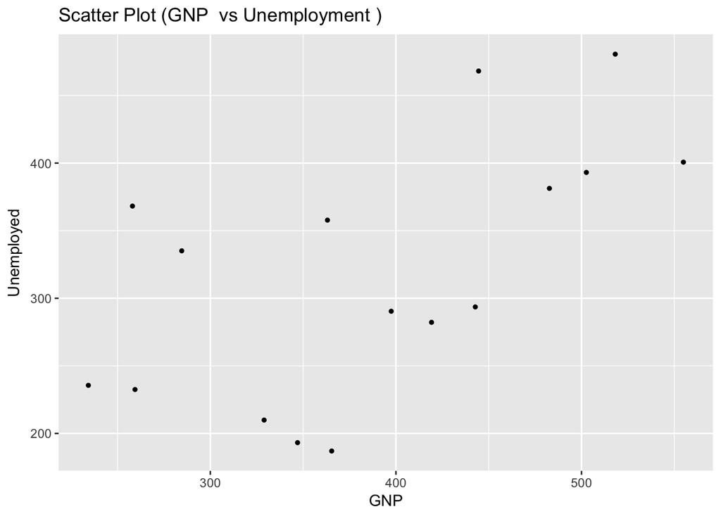

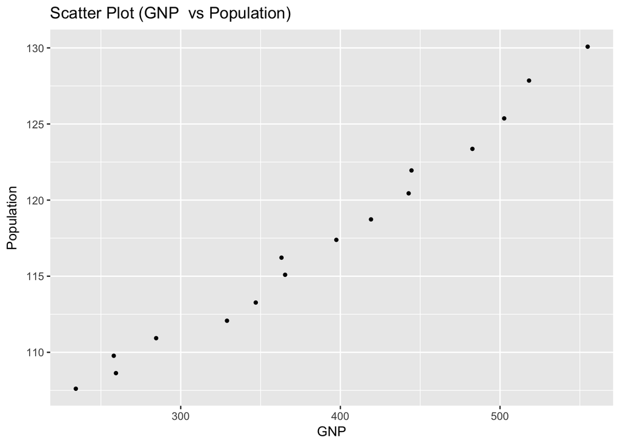

```r
    library(ggplot2)
    ggplot(longley,aes(x=GNP,y=Unemployed)) + geom_point(size=1) + ggtitle("Scatter Plot (GNP  vs Unemployment )")
    ggplot(longley,aes(x=GNP,y=Population)) + geom_point(size=1) + ggtitle("Scatter Plot (GNP  vs Population)")
```

#### Eigen values and Eigen Vectors

Eigen values, generally denoted by $\lambda$, of a square matrix are any scalar values that satisfy the transformation equation $A *V = \lambda*V$. Any $\lambda$ s that satisfies this transformation equation are called eigen values and the corresponding vectors are called eigen vectors. The preceeding equation is also known as the characteristic equation of the matrix A.

In R we calculate the eigen values and vectors as follows.

##### GNP vs Unemployment

```r
  # subset the dataset and calculate the variance-covariance matrix
  t_var_mat <- var(data.frame(longley$GNP,longley$Unemployed))
  t_var_mat
```

|  | longley.GNP | longley.Unemployed |
| --- | --- | --- |
| longley.GNP | 9879.354 | 5612.437 |
| longley.Unemployed | 5612.437 | 8732.234 |

```r
  # calculate the eigen values and eigen vectors
  eig <- eigen(t_var_mat)
```

The eigen values of the variance-covariance matrix are $\lambda$<sub>1</sub> = 14947.462 and $\lambda$<sub>1</sub> = 3664.126. And similarly the eigen vectors corresponding to the eigen values are :

$$\mathbf{V_1} = \left[
\begin{array}
-0.7421809 \\ -0.6701996
\end{array}
\right]$$
$$\mathbf{V_2} = \left[
\begin{array}
0.6701996 \\ -0.7421809
\end{array}
\right]$$

##### GNP vs Population

```r
  # subset the dataset and calculate the variance-covariance matrix
  t_var_mat <- var(data.frame(longley$GNP,longley$Population))
  t_var_mat
```

|  | longley.GNP | longley.Population |
| --- | --- | --- |
| longley.GNP | 9879.3537 | 685.24094 |
| longley.Population | 685.2409 | 48.38735 |

```r
  # calculate the eigen values and eigen vectors
  eig <- eigen(t_var_mat)
```

The eigen values of the variance-covariance matrix are $\lambda$<sub>1</sub> = 9927 and $\lambda$<sub>1</sub> = 0.854. And similarly the eigen vectors corresponding to the eigen values are :

$$\mathbf{V_1} = \left[
\begin{array}
-0.9976028 \\ -0.0692006
\end{array}
\right]$$
$$\mathbf{V_2} = \left[
\begin{array}
0.0692006 \\ -0.9976028
\end{array}
\right]$$